# Pràctica 3 - Mètodes de de Regularització

Axel Romero

29/11/2020

```r
library(leaps)
library(glmnet)
library(pls)
library(tidyverse)
library(ISLR)
```

# 1 Exercici 1

**2- El mètode de Ridge, respecte al mètode de mínims quadrats, és:**

*(i) Més flexible i, per tant, proporcionarà una millor precissió de predicció quan el seu augment en el biaix sigui menor que la disminució de la variança.*

El mètode de Ridge és més flexible que mínims quadrats. Això passa perquè quan el nombre d’observacions ($n$) es va aproximant al nombre de variable ($p$), la variància de les estimacions dels coeficinets augmenta (i.e. canvis petits en la base de dades d’entrenament provoquen canvis grans en les estimacions dels coeficients), i a més, en el cas $n<p$ mínims quadrats no és capaç de donar una solució única, ja que totes les solucions tindran un MSE de cero. En aquesta situació de elevada variància és on millor funciona el mètode de Ridge, i per aquest motiu és més flexible, ja que en la situació $n<p$ podem obtenir una bona estimació dels coeficients.  
Després, el mètode de Ridge, afegint el *shrinkage penalty* el que fa és incrementar el biaix de l’estimació, per aquest motiu, una bona estimació dels coeficients es farà quan la variança es redueix molt i el biaix el mínim possible.

# 2 Exercici 2

**1- A mesura que incrementem $\lambda$, l’error (RSS) del conjunt training:**

*Augmenta de manera constant.*

**A mesura que incrementem $\lambda$, l’error (RSS del conjunt test:**

*Decreix inicialment, i posteriorment comença a augmentar.*

**A mesura que incrementem $\lambda$, la variança:**

*Decreix de manera constant.*

**A mesura que incrementen $\lambda$, el biaix:**

*Augmenta de manera constant.*

# 3 Exercici 3

```r
X.3 <- rnorm(n = 100)
eps.3 <- rnorm(n = 100)
```

```r
beta0.3 <- -10
beta1.3 <- 4
beta2.3 <- 3
beta3.3 <- 0.5
Y.3 <- beta0.3 + beta1.3 * X.3 + beta2.3 * X.3^2 + beta3.3 * X.3^3 + eps.3
df.3 <- data.frame(x = X.3, y = Y.3)
head(df.3)
```

```
##            x          y
## 1  0.1149607 -11.135114
## 2 -1.8710728 -10.692830
## 3  0.2192016  -9.745711
## 4  0.6163149  -5.218943
## 5 -0.2945732 -10.162505
## 6  0.2382820  -9.144731
```

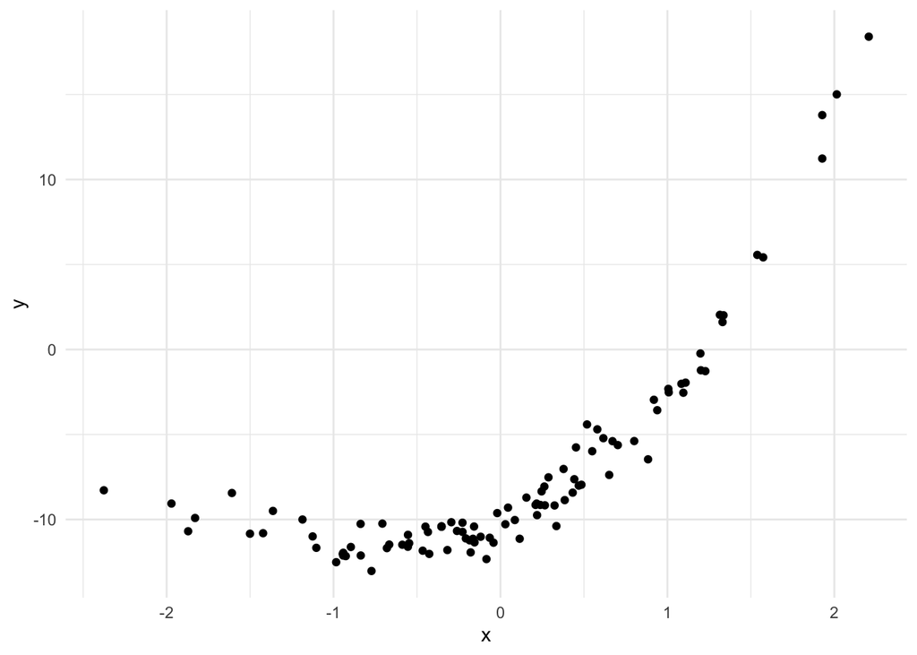

```r
ggplot(df.3, aes(x = x, y = y)) +
  geom_point() + theme_minimal()
```

## 3.1 Millor subconjunt

```r
reg.model.3 <- regsubsets(y ~ poly(x, 10), data = df.3, nvmax = 10)
reg.model.summary.3 <- summary(reg.model.3)
```

```r
par(mfrow = c(2, 2))
plot(reg.model.summary.3$cp, xlab = 'Number of variables', ylab = 'Cp', type = 'o')
points(3, reg.model.summary.3$cp[3], col = 'tomato', pch = 20)
plot(reg.model.summary.3$bic, xlab = 'Number of variables', ylab = 'BIC', type = 'o')
points(3, reg.model.summary.3$bic[3], col = 'tomato', pch = 20)
plot(reg.model.summary.3$adjr2, xlab = 'Number of variables', ylab = 'R2 adj', type = 'o')
points(3, reg.model.summary.3$adjr2[3], col = 'tomato', pch = 20)
par(mfrow = c(1, 1))
```

[output not shown]

```r
coef(reg.model.3, 3)
```

```
##  (Intercept) poly(x, 10)1 poly(x, 10)2 poly(x, 10)3
##    -7.382413    47.128447    35.969686     7.158231
```

## 3.2 Mètode Backward

```r
back.model.3 <- regsubsets(y ~ poly(x, 10), data = df.3, method = 'backward', nvmax = 10)
back.model.summary.3 <- summary(back.model.3)
```

```r
par(mfrow = c(2, 2))
plot(back.model.summary.3$cp, xlab = 'Number of variables', ylab = 'Cp', type = 'o')
points(3, back.model.summary.3$cp[3], col = 'tomato', pch = 20)
plot(back.model.summary.3$bic, xlab = 'Number of variables', ylab = 'BIC', type = 'o')
points(3, back.model.summary.3$bic[3], col = 'tomato', pch = 20)
plot(back.model.summary.3$adjr2, xlab = 'Number of variables', ylab = 'R2 adj', type = 'o')
points(3, back.model.summary.3$adjr2[3], col = 'tomato', pch = 20)
par(mfrow = c(1, 1))
```

[output not shown]

```r
coef(back.model.3, 3)
```

```
##  (Intercept) poly(x, 10)1 poly(x, 10)2 poly(x, 10)3
##    -7.382413    47.128447    35.969686     7.158231
```

## 3.3 Mètode Forward

```r
for.model.3 <- regsubsets(y ~ poly(x, 10), data = df.3, method = 'forward', nvmax = 10)
for.model.summary.3 <- summary(for.model.3)
```

```r
par(mfrow = c(2, 2))
plot(for.model.summary.3$cp, xlab = 'Number of variables', ylab = 'Cp', type = 'o')
points(3, for.model.summary.3$cp[3], col = 'tomato', pch = 20)
plot(for.model.summary.3$bic, xlab = 'Number of variables', ylab = 'BIC', type = 'o')
points(3, for.model.summary.3$bic[3], col = 'tomato', pch = 20)
plot(for.model.summary.3$adjr2, xlab = 'Number of variables', ylab = 'R2 adj', type = 'o')
points(3, for.model.summary.3$adjr2[3], col = 'tomato', pch = 20)
par(mfrow = c(1, 1))
```

[output not shown]

```r
coef(for.model.3, 3)
```

```
##  (Intercept) poly(x, 10)1 poly(x, 10)2 poly(x, 10)3
##    -7.382413    47.128447    35.969686     7.158231
```

## 3.4 LASSO

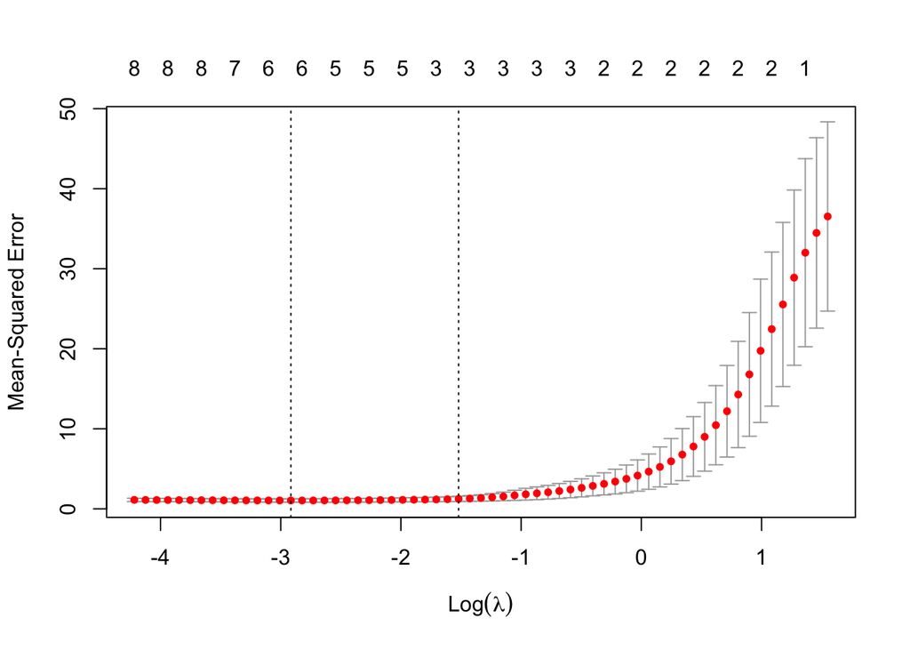

```r
X.mat.3 <- model.matrix(y ~ -1 + poly(x, 10), data = df.3)
Y.mat.3 <- df.3$y
cv.lasso.3 <- cv.glmnet(X.mat.3, Y.mat.3, alpha = 1) # alpha = 1 --> LASSO
plot(cv.lasso.3)
```

```r
coef(cv.lasso.3)
```

```
## 11 x 1 sparse Matrix of class "dgCMatrix"
##                       1
## (Intercept)   -7.382413
## poly(x, 10)1  44.940939
## poly(x, 10)2  33.782177
## poly(x, 10)3   4.970722
## poly(x, 10)4   .
## poly(x, 10)5   .
## poly(x, 10)6   .
## poly(x, 10)7   .
## poly(x, 10)8   .
## poly(x, 10)9   .
## poly(x, 10)10  .
```

```r
beta7.3 <- 6
Y.2.3 <- beta0.3 + beta7.3 * X.3^7 + eps.3
df.2.3 <- data.frame(x = X.3, y = Y.2.3)
head(df.2.3)
```

```
##            x           y
## 1  0.1149607  -11.635362
## 2 -1.8710728 -492.146435
## 3  0.2192016  -10.771785
## 4  0.6163149   -8.738126
## 5 -0.2945732   -9.232906
## 6  0.2382820  -10.274697
```

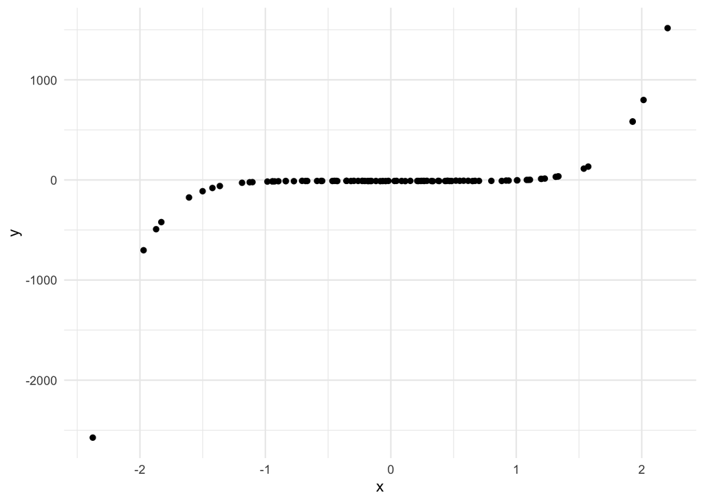

```r
ggplot(df.2.3, aes(x = x, y = y)) +
  geom_point() + theme_minimal()
```

```r
reg.model.2.3 <- regsubsets(y ~ poly(x, 10), data = df.2.3, nvmax = 10)
reg.model.summary.2.3 <- summary(reg.model.2.3)
```

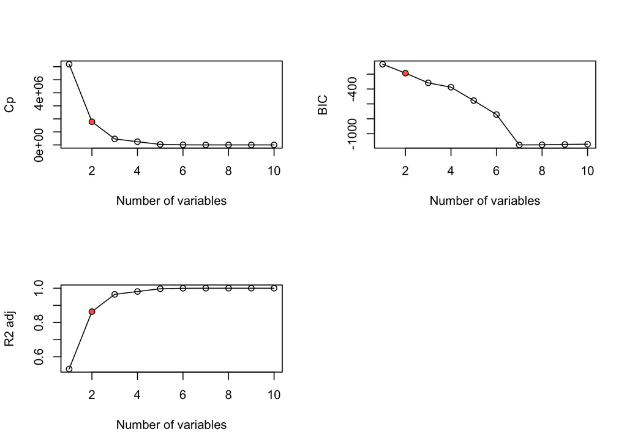

```r
par(mfrow = c(2, 2))
plot(reg.model.summary.2.3$cp, xlab = 'Number of variables', ylab = 'Cp', type = 'o')
points(2, reg.model.summary.2.3$cp[2], col = 'tomato', pch = 20)
plot(reg.model.summary.2.3$bic, xlab = 'Number of variables', ylab = 'BIC', type = 'o')
points(2, reg.model.summary.2.3$bic[2], col = 'tomato', pch = 20)
plot(reg.model.summary.2.3$adjr2, xlab = 'Number of variables', ylab = 'R2 adj', type = 'o')
points(2, reg.model.summary.2.3$adjr2[2], col = 'tomato', pch = 20)
par(mfrow = c(1, 1))
```

```r
coef(reg.model.2.3, 3)
```

```
##  (Intercept) poly(x, 10)1 poly(x, 10)3 poly(x, 10)5
##    -15.81818   1931.16618   2448.49804   1054.89342
```

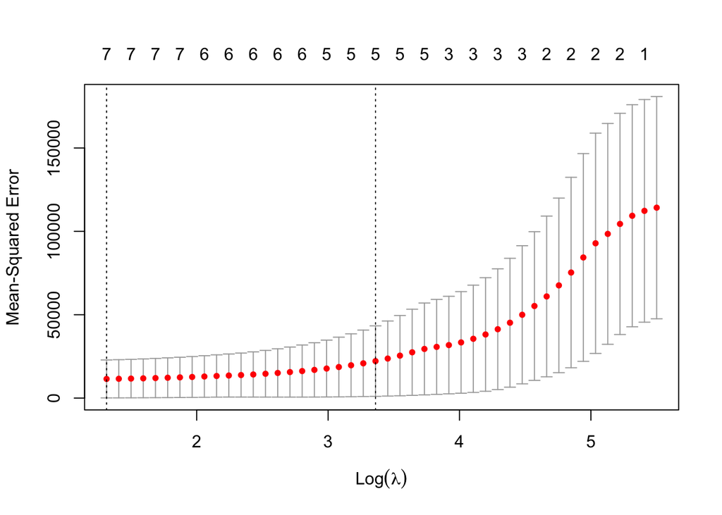

```r
X.mat.2.3 <- model.matrix(y ~ poly(x, 10), data = df.2.3)
Y.mat.2.3 <- df.2.3$y
cv.lasso.2.3 <- cv.glmnet(X.mat.2.3, Y.mat.2.3, alpha = 1)
plot(cv.lasso.2.3)
```

```r
coef(cv.lasso.2.3)
```

```
## 12 x 1 sparse Matrix of class "dgCMatrix"
##                        1
## (Intercept)    -15.81818
## (Intercept)      .
## poly(x, 10)1  1643.02400
## poly(x, 10)2  -139.75237
## poly(x, 10)3  2160.35587
## poly(x, 10)4  -130.14993
## poly(x, 10)5   766.75124
## poly(x, 10)6     .
## poly(x, 10)7     .
## poly(x, 10)8     .
## poly(x, 10)9     .
## poly(x, 10)10    .
```

# 4 Exercici 4

```r
data("College")
glimpse(College)
```

```
## Rows: 777
## Columns: 18
## $ Private     <fct> Yes, Yes, Yes, Yes, Yes, Yes, Yes, Yes, Yes, Yes, Yes, Ye…
## $ Apps        <dbl> 1660, 2186, 1428, 417, 193, 587, 353, 1899, 1038, 582, 17…
## $ Accept      <dbl> 1232, 1924, 1097, 349, 146, 479, 340, 1720, 839, 498, 142…
## $ Enroll      <dbl> 721, 512, 336, 137, 55, 158, 103, 489, 227, 172, 472, 484…
## $ Top10perc   <dbl> 23, 16, 22, 60, 16, 38, 17, 37, 30, 21, 37, 44, 38, 44, 2…
## $ Top25perc   <dbl> 52, 29, 50, 89, 44, 62, 45, 68, 63, 44, 75, 77, 64, 73, 4…
## $ F.Undergrad <dbl> 2885, 2683, 1036, 510, 249, 678, 416, 1594, 973, 799, 183…
## $ P.Undergrad <dbl> 537, 1227, 99, 63, 869, 41, 230, 32, 306, 78, 110, 44, 63…
## $ Outstate    <dbl> 7440, 12280, 11250, 12960, 7560, 13500, 13290, 13868, 155…
## $ Room.Board  <dbl> 3300, 6450, 3750, 5450, 4120, 3335, 5720, 4826, 4400, 338…
## $ Books       <dbl> 450, 750, 400, 450, 800, 500, 500, 450, 300, 660, 500, 40…
## $ Personal    <dbl> 2200, 1500, 1165, 875, 1500, 675, 1500, 850, 500, 1800, 6…
## $ PhD         <dbl> 70, 29, 53, 92, 76, 67, 90, 89, 79, 40, 82, 73, 60, 79, 3…
## $ Terminal    <dbl> 78, 30, 66, 97, 72, 73, 93, 100, 84, 41, 88, 91, 84, 87, …
## $ S.F.Ratio   <dbl> 18.1, 12.2, 12.9, 7.7, 11.9, 9.4, 11.5, 13.7, 11.3, 11.5,…
## $ perc.alumni <dbl> 12, 16, 30, 37, 2, 11, 26, 37, 23, 15, 31, 41, 21, 32, 26…
## $ Expend      <dbl> 7041, 10527, 8735, 19016, 10922, 9727, 8861, 11487, 11644…
## $ Grad.Rate   <dbl> 60, 56, 54, 59, 15, 55, 63, 73, 80, 52, 73, 76, 74, 68, 5…
```

## 4.1 Creació de train i test

```r
size.train <- floor(0.75 * nrow(College))
set.seed(123)
train.id <- sample(seq_len(nrow(College)), size = size.train)
college.train <- College[train.id, ]
college.test <- College[-train.id, ]
dim(college.train)
```

```
## [1] 582  18
```

```r
dim(college.test)
```

```
## [1] 195  18
```

## 4.2 Estimació per mínims quadrats

```r
college.lm <- lm(Apps ~., data = college.train)
college.lm.summary <- summary(college.lm)
college.lm.summary
```

```
##
## Call:
## lm(formula = Apps ~ ., data = college.train)
##
## Residuals:
##     Min      1Q  Median      3Q     Max
## -3262.8  -434.0   -60.1   325.9  6553.2
##
## Coefficients:
##               Estimate Std. Error t value Pr(>|t|)
## (Intercept) -357.51636  455.03029  -0.786 0.432374
## PrivateYes  -634.41730  157.19688  -4.036 6.19e-05 ***
## Accept         1.25726    0.05664  22.198  < 2e-16 ***
## Enroll        -0.27787    0.20084  -1.384 0.167038
## Top10perc     46.23226    6.02057   7.679 7.12e-14 ***
## Top25perc    -14.28980    4.92667  -2.900 0.003871 **
## F.Undergrad    0.09259    0.03576   2.589 0.009872 **
## P.Undergrad    0.01370    0.03441   0.398 0.690564
## Outstate      -0.04842    0.02072  -2.337 0.019785 *
## Room.Board     0.17243    0.05135   3.358 0.000839 ***
## Books          0.17278    0.27453   0.629 0.529365
## Personal      -0.02580    0.07087  -0.364 0.715956
## PhD           -7.50832    5.18958  -1.447 0.148507
## Terminal      -4.40205    5.53844  -0.795 0.427054
## S.F.Ratio      0.30257   14.07008   0.022 0.982851
## perc.alumni   -7.16154    4.53523  -1.579 0.114876
## Expend         0.07847    0.01319   5.950 4.72e-09 ***
## Grad.Rate     10.13370    3.24004   3.128 0.001853 **
## ---
## Signif. codes:  0 '***' 0.001 '**' 0.01 '*' 0.05 '.' 0.1 ' ' 1
##
## Residual standard error: 989.5 on 564 degrees of freedom
## Multiple R-squared:  0.9193, Adjusted R-squared:  0.9169
## F-statistic: 378.1 on 17 and 564 DF,  p-value: < 2.2e-16
```

```r
pred.lm <- predict(college.lm, newdata = college.test)
college.rmspe <- sqrt(mean((college.test$Apps - pred.lm)^2))
college.rmspe
```

```
## [1] 1335.412
```

## 4.3 Ridge

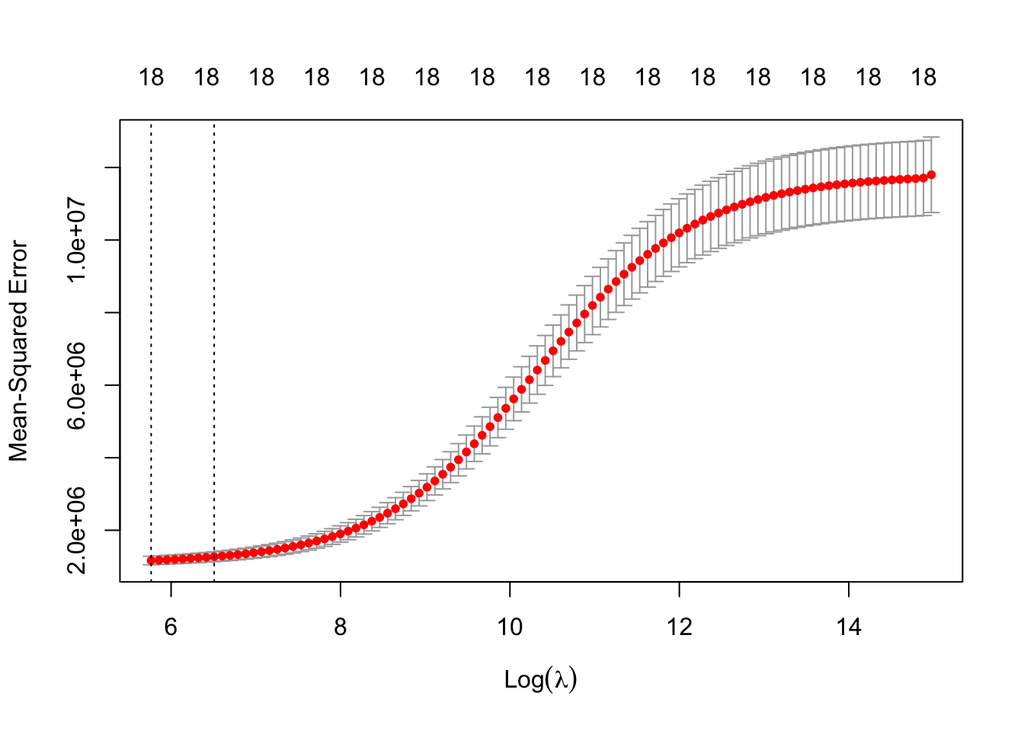

```r
college.X <- model.matrix(Apps ~ -1 + ., data = college.train)
college.Y <- college.train$Apps
cv.ridge <- cv.glmnet(college.X, college.Y, alpha = 0)
plot(cv.ridge)
```

```r
coef(cv.ridge)
```

```
## 19 x 1 sparse Matrix of class "dgCMatrix"
##                         1
## (Intercept) -1.796653e+03
## PrivateNo    3.603857e+02
## PrivateYes  -3.654641e+02
## Accept       6.426203e-01
## Enroll       7.662257e-01
## Top10perc    2.102111e+01
## Top25perc    3.034315e+00
## F.Undergrad  1.350143e-01
## P.Undergrad  4.187490e-03
## Outstate     7.928916e-03
## Room.Board   2.067071e-01
## Books        2.885914e-01
## Personal    -3.549778e-02
## PhD         -1.739478e+00
## Terminal    -3.115724e+00
## S.F.Ratio   -1.415040e+00
## perc.alumni -1.223864e+01
## Expend       7.037848e-02
## Grad.Rate    1.075450e+01
```

```r
college.test.X <- model.matrix(Apps ~ -1 + ., data = college.test)
pred.ridge <- predict(cv.ridge, newx = college.test.X)
rmse.ridge <- sqrt(mean((college.test$Apps - pred.ridge)^2))
rmse.ridge
```

```
## [1] 1995.025
```

## 4.4 LASSO

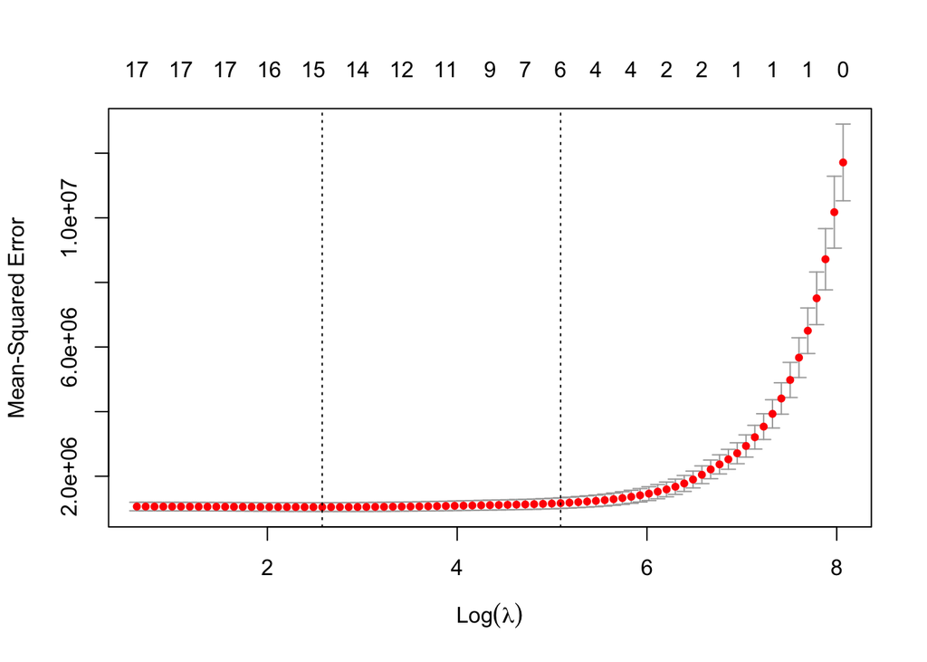

```r
cv.lasso <- cv.glmnet(college.X, college.Y, alpha = 1)
plot(cv.lasso)
```

```r
coef(cv.lasso)
```

```
## 19 x 1 sparse Matrix of class "dgCMatrix"
##                         1
## (Intercept) -7.270252e+02
## PrivateNo    9.782514e+01
## PrivateYes  -1.332796e-11
## Accept       1.210420e+00
## Enroll       .
## Top10perc    2.347055e+01
## Top25perc    .
## F.Undergrad  5.829403e-02
## P.Undergrad  .
## Outstate     .
## Room.Board   .
## Books        .
## Personal     .
## PhD          .
## Terminal     .
## S.F.Ratio    .
## perc.alumni  .
## Expend       4.197544e-02
## Grad.Rate    .
```

```r
pred.lasso <- predict(cv.lasso, newx = college.test.X)
rmse.lasso <- sqrt(mean((college.test$Apps - pred.lasso)^2))
rmse.lasso
```

```
## [1] 1423.517
```

## 4.5 PCR

```r
set.seed(12)
college.pcr <- pcr(Apps ~., data = college.train, scale = T, validation = 'CV')
summary(college.pcr)
```

```
## Data:    X dimension: 582 17
##  Y dimension: 582 1
## Fit method: svdpc
## Number of components considered: 17
##
## VALIDATION: RMSEP
## Cross-validated using 10 random segments.
##        (Intercept)  1 comps  2 comps  3 comps  4 comps  5 comps  6 comps
## CV            3436     3407     1693     1666     1396     1329     1291
## adjCV         3436     3406     1691     1662     1382     1311     1286
##        7 comps  8 comps  9 comps  10 comps  11 comps  12 comps  13 comps
## CV        1236     1222     1174      1175      1179      1180      1183
## adjCV     1217     1215     1171      1173      1177      1177      1180
##        14 comps  15 comps  16 comps  17 comps
## CV         1184      1197      1055      1041
## adjCV      1181      1194      1051      1037
##
## TRAINING: % variance explained
##       1 comps  2 comps  3 comps  4 comps  5 comps  6 comps  7 comps  8 comps
## X      31.795    57.66    64.42    70.01    75.27    80.29    83.84    87.32
## Apps    2.888    76.55    77.79    84.78    86.17    86.88    88.22    88.23
##       9 comps  10 comps  11 comps  12 comps  13 comps  14 comps  15 comps
## X       90.52     92.99     95.06     96.94     98.02     98.87     99.39
## Apps    89.08     89.09     89.12     89.17     89.20     89.20     89.29
##       16 comps  17 comps
## X        99.80    100.00
## Apps     91.62     91.93
```

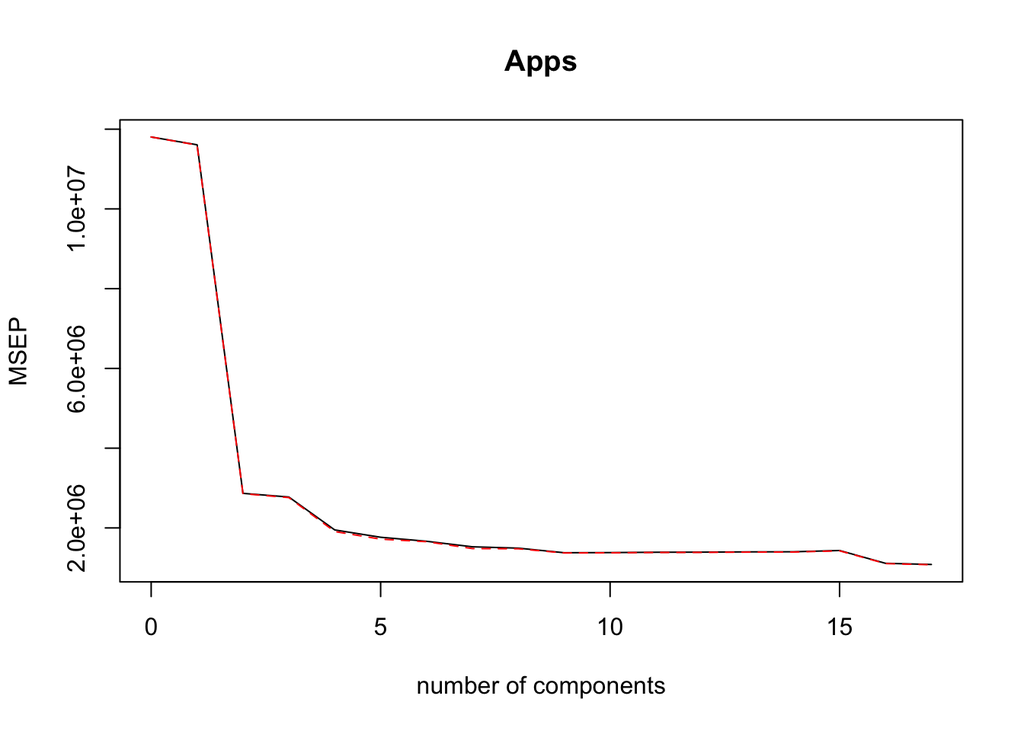

```r
validationplot(college.pcr, val.type = 'MSEP')
```

```r
college.pcr.fit <- pcr(Apps ~ ., data = college.train, scale = T, ncomp = 4)
summary(college.pcr.fit)
```

```
## Data:    X dimension: 582 17
##  Y dimension: 582 1
## Fit method: svdpc
## Number of components considered: 4
## TRAINING: % variance explained
##       1 comps  2 comps  3 comps  4 comps
## X      31.795    57.66    64.42    70.01
## Apps    2.888    76.55    77.79    84.78
```

```r
pred.pcr <- predict(college.pcr.fit, newdata = college.test)
rmse.pcr <- sqrt(mean((college.test$Apps - pred.pcr)^2))
rmse.pcr
```

```
## [1] 3336.089
```

## 4.6 PLS

```r
set.seed(12)
college.pls <- plsr(Apps ~., data = college.train, scale = T)
summary(college.pls)
```

```
## Data:    X dimension: 582 17
##  Y dimension: 582 1
## Fit method: kernelpls
## Number of components considered: 17
## TRAINING: % variance explained
##       1 comps  2 comps  3 comps  4 comps  5 comps  6 comps  7 comps  8 comps
## X       26.06    41.86    63.05    67.24    71.07    73.81    77.53    80.75
## Apps    81.08    87.14    89.47    90.26    91.10    91.80    91.86    91.89
##       9 comps  10 comps  11 comps  12 comps  13 comps  14 comps  15 comps
## X       83.10     85.31     88.90     90.81     92.85     93.80     95.79
## Apps    91.91     91.92     91.93     91.93     91.93     91.93     91.93
##       16 comps  17 comps
## X        98.82    100.00
## Apps     91.93     91.93
```

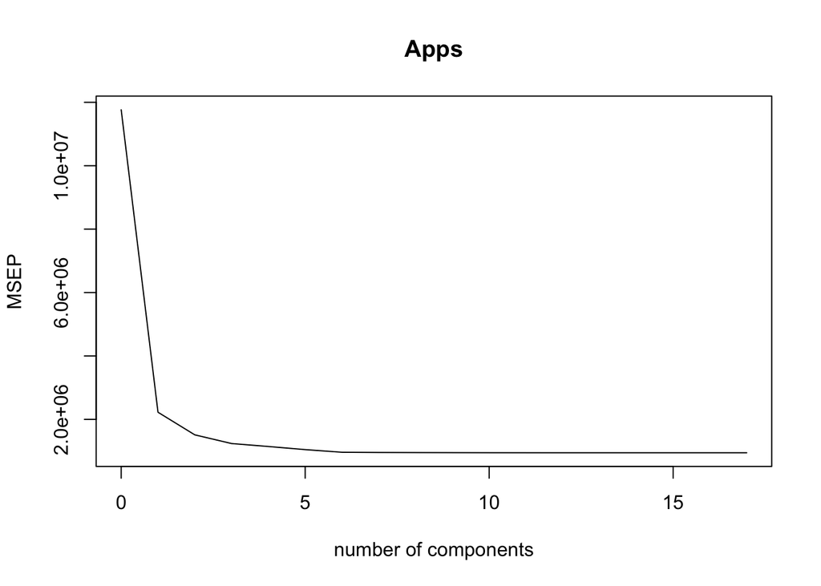

```r
validationplot(college.pls, val.type = 'MSEP')
```

```r
college.pls.fit <- plsr(Apps ~., data = college.train, scale = T, ncomp = 2)
summary(college.pls.fit)
```

```
## Data:    X dimension: 582 17
##  Y dimension: 582 1
## Fit method: kernelpls
## Number of components considered: 2
## TRAINING: % variance explained
##       1 comps  2 comps
## X       26.06    41.86
## Apps    81.08    87.14
```

```r
pred.pls <- predict(college.pls.fit, newdata = college.test)
rmse.pls <- sqrt(mean((college.test$Apps - pred.pls)^2))
rmse.pls
```

```
## [1] 2356.017
```

```r
college.reg <- regsubsets(Apps ~., data = college.train, nvmax = 19)
college.summary.reg <- summary(college.reg)
```

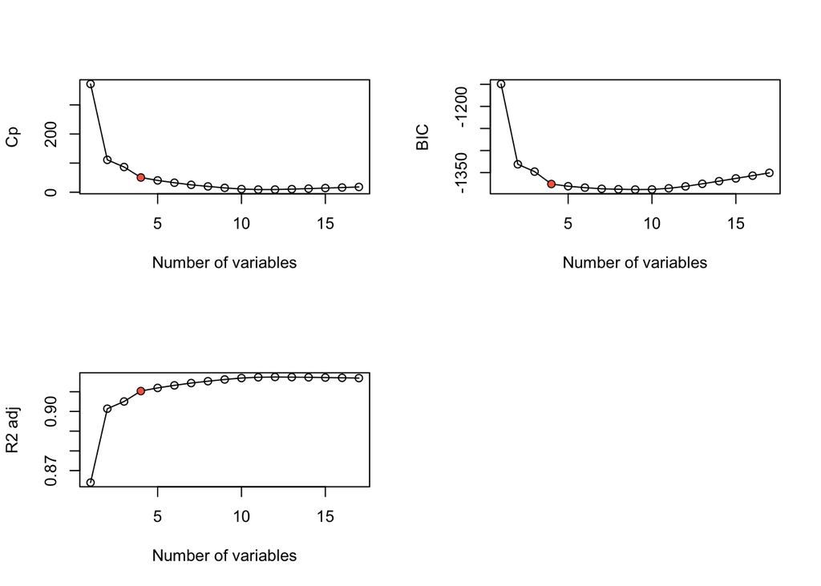

```r
par(mfrow = c(2, 2))
plot(college.summary.reg$cp, xlab = 'Number of variables', ylab = 'Cp', type = 'o')
points(4, college.summary.reg$cp[4], col = 'tomato', pch = 20)
plot(college.summary.reg$bic, xlab = 'Number of variables', ylab = 'BIC', type = 'o')
points(4, college.summary.reg$bic[4], col = 'tomato', pch = 20)
plot(college.summary.reg$adjr2, xlab = 'Number of variables', ylab = 'R2 adj', type = 'o')
points(4, college.summary.reg$adjr2[4], col = 'tomato', pch = 20)
par(mfrow = c(1, 1))
```

```r
X.test <- model.matrix(Apps ~., data = college.test)
coefi.reg <-coef(college.reg, 4)
pred.reg <- X.test[,names(coefi.reg)] %*% as.matrix(coefi.reg)
rmse.reg <- sqrt(mean((college.test$Apps - pred.reg)^2))
rmse.reg
```

```
## [1] 1319.174
```